# Assessing Pesticide Contamination in Illinois Water Supply and the Impact of Agricultural Practices

Ammonia average yearly increase (Jo Daviess county of interest)

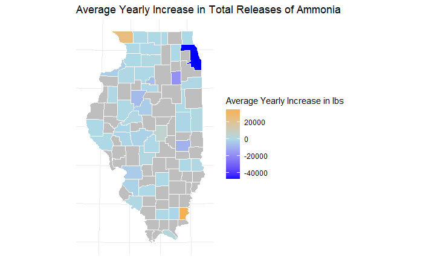

```r
plot_avg_yearly_increase("Ammonia", chemical_by_county, illinois_counties)
```

Benzene average yearly increase (Benzene generally decreasing)

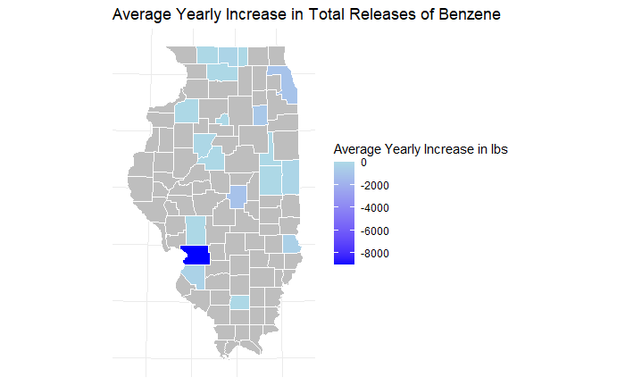

```r
plot_avg_yearly_increase("Benzene", chemical_by_county, illinois_counties)
```

2,4-D average yearly increase (Cook county of interest)

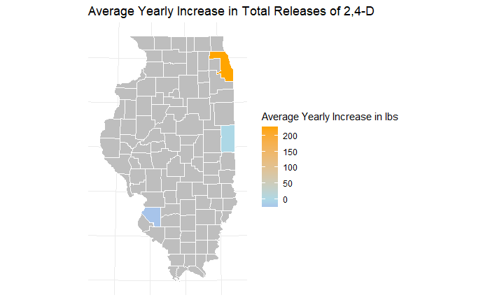

```r
plot_avg_yearly_increase("2,4-D", chemical_by_county, illinois_counties)
```

Mercury average yearly increase

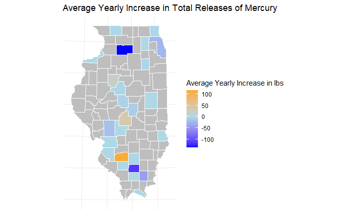

```r
plot_avg_yearly_increase("Mercury", chemical_by_county, illinois_counties)
```

Hydrazine average yearly increase

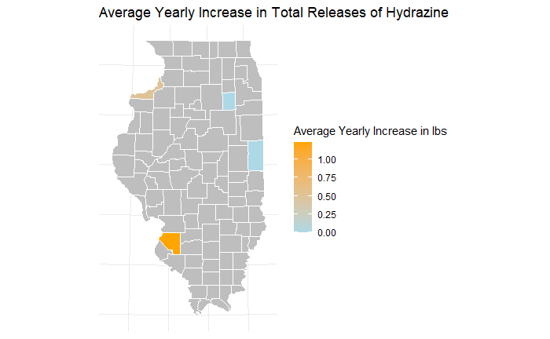

```r
plot_avg_yearly_increase("Hydrazine", chemical_by_county, illinois_counties)
```

Atrazine average yearly increase

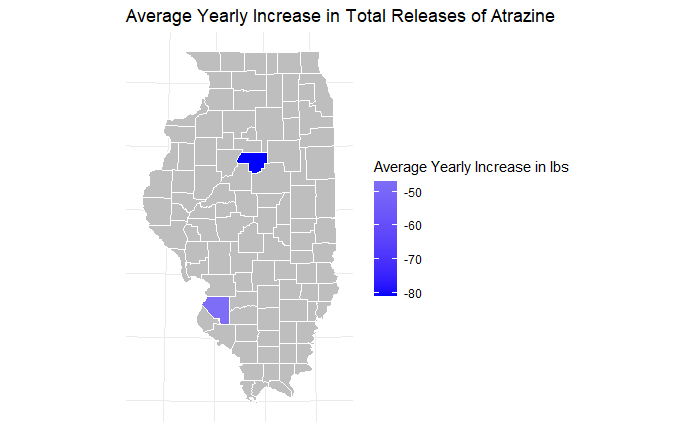

```r
plot_avg_yearly_increase("Atrazine", chemical_by_county, illinois_counties)
```

Acetochlor shows no reported releases

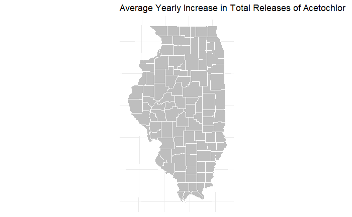

```r
plot_avg_yearly_increase("Acetochlor", chemical_by_county, illinois_counties)
```

```
                                         USGS WATER QUALITY DATASET ANALYSIS SECTION
```

1. Load in and format the USGS data

```r
chemical_data <- fread("C:/Users/carso/Downloads/waterdata/waterdata.csv", sep = "\t", fill = TRUE, quote = "")
```

```
|--------------------------------------------------|
|==================================================|
```

```r
# Format date field
chemical_data$sample_dt <- as.Date(chemical_data$sample_dt, format="%Y-%m-%d")
chemical_data <- chemical_data %>% drop_na(result_va)
```

Examine data

```r
head(chemical_data)
```

| agency_cd | site_no | sample_dt | sample_tm | sample_end_dt | sample_end_tm | sample_start_time_datum_cd | tm_datum_rlbty_cd | coll_ent_cd | medium_cd | project_cd | aqfr_cd | tu_id | body_part_id | hyd_cond_cd | samp_type_cd | hyd_event_cd | sample_lab_cm_tx | parm_cd | remark_cd | result_va | val_qual_tx | meth_cd | dqi_cd | rpt_lev_va | rpt_lev_cd | lab_std_va | prep_set_no | prep_dt | anl_set_no | … |
| --- | --- | --- | --- | --- | --- | --- | --- | --- | --- | --- | --- | --- | --- | --- | --- | --- | --- | --- | --- | --- | --- | --- | --- | --- | --- | --- | --- | --- | --- | --- |
| USGS | 3384500 | 1955-10-01 |  | 1955-10-10 |  | CST | T |  | WS |  |  | NA | NA | A | 9 | 9 |  | 49 |  | 1.439e+05 |  |  | A | NA |  | NA |  | NA |  | … |
| USGS | 3384500 | 1955-10-01 |  | 1955-10-10 |  | CST | T |  | WS |  |  | NA | NA | A | 9 | 9 |  | 80 |  | 5.000e+00 |  |  | A | NA |  | NA |  | NA |  | … |
| USGS | 3384500 | 1955-10-01 |  | 1955-10-10 |  | CST | T |  | WS |  |  | NA | NA | A | 9 | 9 |  | 95 |  | 5.690e+02 |  |  | A | NA |  | NA |  | NA |  | … |
| USGS | 3384500 | 1955-10-01 |  | 1955-10-10 |  | CST | T |  | WS |  |  | NA | NA | A | 9 | 9 |  | 191 |  | 3.000e-05 |  | ALGOR | A | NA |  | NA |  | NA |  | … |
| USGS | 3384500 | 1955-10-01 |  | 1955-10-10 |  | CST | T |  | WS |  |  | NA | NA | A | 9 | 9 |  | 400 |  | 7.500e+00 |  |  | A | NA |  | NA |  | NA |  | … |
| USGS | 3384500 | 1955-10-01 |  | 1955-10-10 |  | CST | T |  | WS |  |  | NA | NA | A | 9 | 9 |  | 405 |  | 5.000e+00 |  | ALGOR | A | NA |  | NA |  | NA |  | … |

```r
summary(chemical_data)
```

```
  agency_cd            site_no                  sample_dt           sample_tm         sample_end_dt        sample_end_tm      sample_start_time_datum_cd
 Length:3742875     Min.   :        3336280   Min.   :1901-01-02   Length:3742875     Min.   :1951-05-31   Length:3742875     Length:3742875
 Class :character   1st Qu.:        5527500   1st Qu.:1984-11-05   Class :character   1st Qu.:1957-06-30   Class :character   Class :character
 Mode  :character   Median :        5572000   Median :1989-10-31   Mode  :character   Median :1981-06-16   Mode  :character   Mode  :character
                    Mean   : 63559090058734   Mean   :1992-11-10                      Mean   :1979-03-01
                    3rd Qu.:        5595200   3rd Qu.:1997-01-07                      3rd Qu.:1990-06-21
                    Max.   :423784088133401   Max.   :2024-03-08                      Max.   :2020-02-20
                                              NA's   :3534                            NA's   :3725526
 tm_datum_rlbty_cd  coll_ent_cd         medium_cd          project_cd          aqfr_cd              tu_id          body_part_id     hyd_cond_cd        samp_type_cd
 Length:3742875     Length:3742875     Length:3742875     Length:3742875     Length:3742875     Min.   :     0    Min.   : 6        Length:3742875     Length:3742875
 Class :character   Class :character   Class :character   Class :character   Class :character   1st Qu.:     0    1st Qu.:59        Class :character   Class :character
 Mode  :character   Mode  :character   Mode  :character   Mode  :character   Mode  :character   Median :     0    Median :94        Mode  :character   Mode  :character
                                                                                                Mean   : 73193    Mean   :69
                                                                                                3rd Qu.:163344    3rd Qu.:94
                                                                                                Max.   :163998    Max.   :94
                                                                                                NA's   :3737504   NA's   :3737504
 hyd_event_cd       sample_lab_cm_tx      parm_cd       remark_cd           result_va          val_qual_tx          meth_cd             dqi_cd            rpt_lev_va
 Length:3742875     Length:3742875     Min.   :    1   Length:3742875     Min.   :-3.830e+02   Length:3742875     Length:3742875     Length:3742875     Min.   :    0
 Class :character   Class :character   1st Qu.:  610   Class :character   1st Qu.: 1.000e+00   Class :character   Class :character   Class :character   1st Qu.:    0
 Mode  :character   Mode  :character   Median : 1027   Mode  :character   Median : 8.000e+00   Mode  :character   Mode  :character   Mode  :character   Median :    1
                                       Mean   :18787                      Mean   : 9.134e+03                                                            Mean   :   28
                                       3rd Qu.:32730                      3rd Qu.: 6.300e+01                                                            3rd Qu.:    8
                                       Max.   :99995                      Max.   : 1.000e+10                                                            Max.   :18950
                                                                                                                                                        NA's   :3308987
  rpt_lev_cd          lab_std_va      prep_set_no           prep_dt          anl_set_no            anl_dt         result_lab_cm_tx    anl_ent_cd          V34
 Length:3742875     Min.   :      0   Length:3742875     Min.   :20010530   Length:3742875     Min.   :20010606   Length:3742875     Length:3742875     Mode:logical
 Class :character   1st Qu.:      0   Class :character   1st Qu.:20110624   Class :character   1st Qu.:20091114   Class :character   Class :character   NA's:3742875
 Mode  :character   Median :      0   Mode  :character   Median :20130916   Mode  :character   Median :20130825   Mode  :character   Mode  :character
                    Mean   :    955                      Mean   :20137288                      Mean   :20133588
                    3rd Qu.:      1                      3rd Qu.:20170814                      3rd Qu.:20170731
                    Max.   :1301508                      Max.   :20240221                      Max.   :20240307
                    NA's   :3741510                      NA's   :3421702                       NA's   :3282264
```

2. Load in and format parameter data

```r
param_data <- read.delim("C:/Users/carso/Downloads/waterdata/param_dictionary.txt", sep = "\t", header = FALSE, stringsAsFactors = FALSE, col.names = "field")

# Format param data so we can match it. Don't need field
param_data <- param_data %>%
  mutate(
    parm_cd = as.numeric(sub(" - .*", "", field)),
    description = sub("^[0-9]+ - ", "", field)
  ) %>%
  select(-field)
```

3. Function for filtering by chemicals in the parameter codes and using a SARIMA model to forecast

```r
forecast_chemical <- function(chemical_name, start_date, param_data, chemical_data, forecast_horizon = 36) {

  # Get data for chemical of interest using grepl
  data <- param_data %>%
    filter(grepl(chemical_name, description, ignore.case = TRUE))

  # Get parameter codes that match that chemical and select data after start date
  filtered_chemical_data_after_start <- chemical_data %>%
    filter(parm_cd %in% data$parm_cd, sample_dt > as.Date(start_date)) %>%
    select(site_no, sample_dt, sample_end_dt, result_va, result_lab_cm_tx) %>%
    mutate(year_month = format(sample_dt, "%Y-%m"))

  # Get outlier threshold
  outlier_threshold <- quantile(filtered_chemical_data_after_start$result_va, 0.99, na.rm = TRUE)

  # Remove outliers above the threshold
  filtered_chemical_data_no_outliers <- filtered_chemical_data_after_start %>%
    filter(result_va <= outlier_threshold)

  # Get data by year month and get mean
  data_by_month <- filtered_chemical_data_no_outliers %>%
    group_by(year_month) %>%
    summarise(result_va = mean(result_va, na.rm = TRUE)) %>%
    ungroup() %>%
    arrange(year_month)

  # Convert year month to date
  data_by_month <- data_by_month %>%
    mutate(year_month = as.Date(paste0(year_month, "-01")))

  # Create time series using the data
  result_va_ts_monthly <- ts(
    data_by_month$result_va,
    start = c(
      as.numeric(format(min(data_by_month$year_month), "%Y")),
      as.numeric(format(min(data_by_month$year_month), "%m"))
    ),
    frequency = 12
  )

  # Fit SARIMA model
  sarima_model <- auto.arima(result_va_ts_monthly, seasonal = TRUE)

  # Get forecast
  forecast_monthly <- forecast(sarima_model, h = forecast_horizon)

  # Plot forecast
  plot(
    forecast_monthly,
    main = paste("Forecast of Monthly Average result_va for", chemical_name),
    xlab = "Year",
    ylab = "Average Amount in Water Supply"
  )

  # Extract forecasted values
  forecast_values <- as.data.frame(forecast_monthly)$`Point Forecast`

  # Calculate the difference between the first and last forecasted values
  forecast_increase <- forecast_values[length(forecast_values)] - forecast_values[1]

  # Print increase or decrease
  if (forecast_increase > 0) {
    cat("The forecast indicates an increase of", forecast_increase, "over the next", forecast_horizon, "months.\n")
  } else if (forecast_increase < 0) {
    cat("The forecast indicates a decrease of", abs(forecast_increase), "over the next", forecast_horizon, "months.\n")
  } else {
    cat("The forecast indicates no significant change over the forecast period.")
  }

  # Print summary
  print(summary(sarima_model))

  # Return the forecast and model summary
  return(list(
    model = sarima_model,
    forecast = forecast_monthly
  ))

}
```

2,4-D SARIMA forecast post 2014 since the EPA approved use in 2014. It picks up a decrease but when reading the chart you can see its just the top end of the season its starting at so note this as possible increase

```
The forecast indicates a decrease of 4.559721 over the next 36 months.
Series: result_va_ts_monthly
ARIMA(1,0,0)(1,0,0)[12] with non-zero mean

Coefficients:
         ar1    sar1      mean
      0.2180  0.4260  103.8303
s.e.  0.0899  0.0846    6.4850

sigma^2 = 1177:  log likelihood = -579.34
AIC=1166.69   AICc=1167.05   BIC=1177.74

Training set error measures:
                    ME    RMSE      MAE       MPE     MAPE      MASE         ACF1
Training set 0.1651061 33.8604 25.16816 -7.974954 24.06877 0.8373728 -0.006531367
```

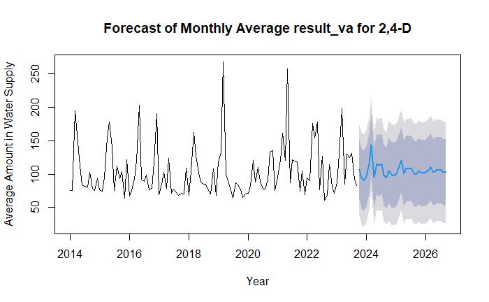

```r
result <- forecast_chemical(
  chemical_name = "2,4-D",
  start_date = "2014-01-01",
  param_data = param_data,
  chemical_data = chemical_data,
  forecast_horizon = 36
)
```

```r
result
```

```
$model
Series: result_va_ts_monthly
ARIMA(1,0,0)(1,0,0)[12] with non-zero mean

Coefficients:
         ar1    sar1      mean
      0.2180  0.4260  103.8303
s.e.  0.0899  0.0846    6.4850

sigma^2 = 1177:  log likelihood = -579.34
AIC=1166.69   AICc=1167.05   BIC=1177.74

$forecast
```

|  | Point Forecast | Lo 80 | Hi 80 | Lo 95 | Hi 95 |
| --- | --- | --- | --- | --- | --- |
| Oct 2023 | 106.73410 | 62.77299 | 150.6952 | 39.50138 | 173.9668 |
| Nov 2023 | 93.95748 | 48.96375 | 138.9512 | 25.14550 | 162.7695 |
| Dec 2023 | 90.04299 | 45.00077 | 135.0852 | 21.15685 | 158.9291 |
| Jan 2024 | 96.62030 | 51.57577 | 141.6648 | 27.73064 | 165.5100 |
| Feb 2024 | 115.11246 | 70.06782 | 160.1571 | 46.22263 | 184.0023 |
| Mar 2024 | 143.82212 | 98.77747 | 188.8668 | 74.93227 | 212.7120 |
| Apr 2024 | 95.64435 | 50.59971 | 140.6890 | 26.75451 | 164.5342 |
| May 2024 | 114.85187 | 69.80723 | 159.8965 | 45.96203 | 183.7417 |
| Jun 2024 | 112.65474 | 67.61009 | 157.6994 | 43.76490 | 181.5446 |
| Jul 2024 | 115.21937 | 70.17472 | 160.2640 | 46.32952 | 184.1092 |

[output cut: 26 more lines]

```
NA
```

Ammonia SARIMA forecast. Slight increase detected though it starts at the bottom of the season. Peaks are higher for years post 2020.

```
The forecast indicates an increase of 0.3990033 over the next 36 months.
Series: result_va_ts_monthly
ARIMA(1,0,1)(1,0,0)[12] with non-zero mean

Coefficients:
         ar1      ma1    sar1    mean
      0.6366  -0.1770  0.2611  1.4056
s.e.  0.0826   0.1033  0.0624  0.0713

sigma^2 = 0.1626:  log likelihood = -144.12
AIC=298.24   AICc=298.45   BIC=316.5

Training set error measures:
                       ME      RMSE       MAE       MPE     MAPE      MASE         ACF1
Training set -0.003353968 0.4003976 0.3046954 -10.10617 25.75158 0.7259315 -0.006283936
```

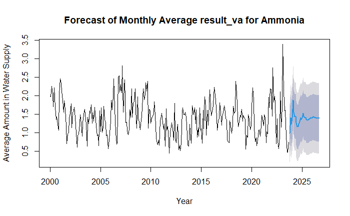

```r
result <- forecast_chemical(
  chemical_name = "Ammonia",
  start_date = "2000-01-01",
  param_data = param_data,
  chemical_data = chemical_data,
  forecast_horizon = 36
)
```

```r
result
```

```
$model
Series: result_va_ts_monthly
ARIMA(1,0,1)(1,0,0)[12] with non-zero mean

Coefficients:
         ar1      ma1    sar1    mean
      0.6366  -0.1770  0.2611  1.4056
s.e.  0.0826   0.1033  0.0624  0.0713

sigma^2 = 0.1626:  log likelihood = -144.12
AIC=298.24   AICc=298.45   BIC=316.5

$forecast
```

|  | Point Forecast | Lo 80 | Hi 80 | Lo 95 | Hi 95 |
| --- | --- | --- | --- | --- | --- |
| Oct 2023 | 0.994671 | 0.4779016 | 1.511440 | 0.2043404 | 1.785002 |
| Nov 2023 | 1.409832 | 0.8411104 | 1.978553 | 0.5400476 | 2.279615 |
| Dec 2023 | 1.225905 | 0.6374376 | 1.814373 | 0.3259215 | 2.125889 |
| Jan 2024 | 1.408235 | 0.8119518 | 2.004518 | 0.4962985 | 2.320171 |
| Feb 2024 | 1.878981 | 1.2795596 | 2.478401 | 0.9622454 | 2.795716 |
| Mar 2024 | 1.557139 | 0.9564509 | 2.157826 | 0.6384660 | 2.475811 |
| Apr 2024 | 1.435825 | 0.8346245 | 2.037025 | 0.5163684 | 2.355281 |
| May 2024 | 1.447479 | 0.8460711 | 2.048887 | 0.5277050 | 2.367253 |
| Jun 2024 | 1.265575 | 0.6640833 | 1.867067 | 0.3456727 | 2.185478 |
| Jul 2024 | 1.158952 | 0.5574259 | 1.760478 | 0.2389973 | 2.078906 |

[output cut: 26 more lines]

```
NA
```

```
The forecast indicates an increase of 9.810902 over the next 60 months.
Series: result_va_ts_monthly
ARIMA(1,0,0)(0,1,2)[12] with drift

Coefficients:
         ar1     sma1    sma2   drift
      0.3471  -0.6308  0.1374  0.8493
s.e.  0.0586   0.0626  0.0596  0.4157

sigma^2 = 10762:  log likelihood = -1655.09
AIC=3320.18   AICc=3320.4   BIC=3338.23

Training set error measures:
                    ME     RMSE     MAE       MPE     MAPE      MASE        ACF1
Training set -0.261197 100.7862 43.3391 -5201.369 5237.927 0.8554528 -0.02752251
```

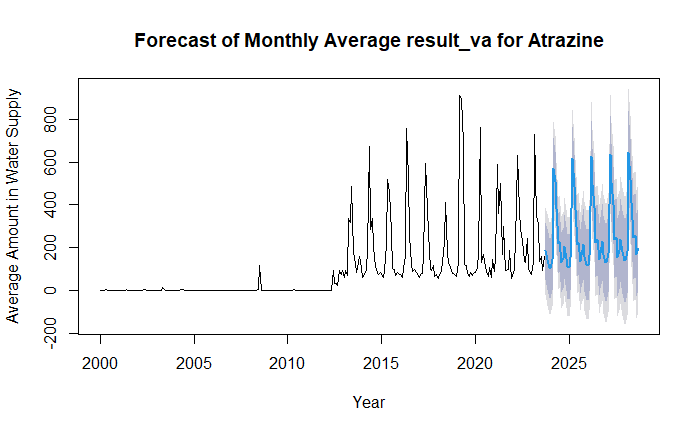

```r
result <- forecast_chemical(
  chemical_name = "Atrazine",
  start_date = "2000-01-01",
  param_data = param_data,
  chemical_data = chemical_data,
  forecast_horizon = 60
)
```

```r
result
```

```
$model
Series: result_va_ts_monthly
ARIMA(1,0,0)(0,1,2)[12] with drift

Coefficients:
         ar1     sma1    sma2   drift
      0.3471  -0.6308  0.1374  0.8493
s.e.  0.0586   0.0626  0.0596  0.4157

sigma^2 = 10762:  log likelihood = -1655.09
AIC=3320.18   AICc=3320.4   BIC=3338.23

$forecast
```

|  | Point Forecast | Lo 80 | Hi 80 | Lo 95 | Hi 95 |
| --- | --- | --- | --- | --- | --- |
| Oct 2023 | 185.3289 | 52.380483 | 318.2774 | -17.998174 | 388.6560 |
| Nov 2023 | 146.7128 | 5.983487 | 287.4421 | -68.514116 | 361.9397 |
| Dec 2023 | 105.3472 | -36.290642 | 246.9851 | -111.269209 | 321.9637 |
| Jan 2024 | 102.6465 | -39.100410 | 244.3935 | -114.136714 | 319.4298 |
| Feb 2024 | 143.6000 | 1.839930 | 285.3601 | -73.203327 | 360.4034 |
| Mar 2024 | 571.4437 | 429.682035 | 713.2054 | 354.637941 | 788.2495 |
| Apr 2024 | 509.5392 | 367.777377 | 651.3011 | 292.733182 | 726.3453 |
| May 2024 | 382.9636 | 241.201671 | 524.7254 | 166.157463 | 599.7696 |
| Jun 2024 | 219.1350 | 77.373074 | 360.8968 | 2.328865 | 435.9411 |
| Jul 2024 | 228.8925 | 87.130655 | 370.6544 | 12.086446 | 445.6986 |

[output cut: 50 more lines]

```
NA
```

```
The forecast indicates a decrease of 24.82873 over the next 60 months.
Series: result_va_ts_monthly
ARIMA(1,0,0)(2,0,0)[12] with non-zero mean

Coefficients:
         ar1    sar1    sar2      mean
      0.4224  0.4888  0.1316  186.4247
s.e.  0.0769  0.0848  0.0850   52.9737

sigma^2 = 26271:  log likelihood = -918.06
AIC=1846.12   AICc=1846.56   BIC=1860.86

Training set error measures:
                   ME     RMSE      MAE       MPE     MAPE      MASE       ACF1
Training set 7.044405 159.7668 80.60892 -3622.318 3639.897 0.8120273 0.01773624
```

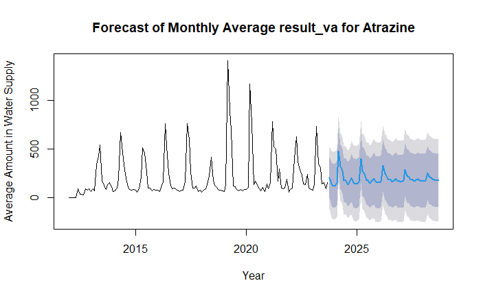

```r
result <- forecast_chemical(
  chemical_name = "Atrazine",
  start_date = "2012-01-01",
  param_data = param_data,
  chemical_data = chemical_data,
  forecast_horizon = 60
)
```

```r
result
```

```
$model
Series: result_va_ts_monthly
ARIMA(1,0,0)(2,0,0)[12] with non-zero mean

Coefficients:
         ar1    sar1    sar2      mean
      0.4224  0.4888  0.1316  186.4247
s.e.  0.0769  0.0848  0.0850   52.9737

sigma^2 = 26271:  log likelihood = -918.06
AIC=1846.12   AICc=1846.56   BIC=1860.86

$forecast
```

|  | Point Forecast | Lo 80 | Hi 80 | Lo 95 | Hi 95 |
| --- | --- | --- | --- | --- | --- |
| Oct 2023 | 206.7542 | -0.9627693 | 414.4711 | -110.92147 | 524.4298 |
| Nov 2023 | 144.3263 | -81.1631498 | 369.8158 | -200.53006 | 489.1827 |
| Dec 2023 | 119.8762 | -108.6393367 | 348.3918 | -229.60817 | 469.3606 |
| Jan 2024 | 119.2531 | -109.7982370 | 348.3045 | -231.05070 | 469.5569 |
| Feb 2024 | 150.2334 | -78.9134265 | 379.3802 | -200.21643 | 500.6832 |
| Mar 2024 | 481.0344 | 251.8705034 | 710.1982 | 130.55849 | 831.5102 |
| Apr 2024 | 321.8427 | 92.6757852 | 551.0096 | -28.63784 | 672.3232 |
| May 2024 | 272.9874 | 43.8199581 | 502.1548 | -77.49396 | 623.4687 |
| Jun 2024 | 175.2758 | -53.8917552 | 404.4433 | -175.20572 | 525.7573 |
| Jul 2024 | 178.1494 | -51.0181315 | 407.3170 | -172.33211 | 528.6309 |

[output cut: 50 more lines]

```
NA
```

```
The forecast indicates a decrease of 30.01999 over the next 36 months.
Series: result_va_ts_monthly
ARIMA(1,0,0)(2,0,0)[12] with non-zero mean

Coefficients:
         ar1    sar1    sar2      mean
      0.4224  0.4888  0.1316  186.4247
s.e.  0.0769  0.0848  0.0850   52.9737

sigma^2 = 26271:  log likelihood = -918.06
AIC=1846.12   AICc=1846.56   BIC=1860.86

Training set error measures:
                   ME     RMSE      MAE       MPE     MAPE      MASE       ACF1
Training set 7.044405 159.7668 80.60892 -3622.318 3639.897 0.8120273 0.01773624
```

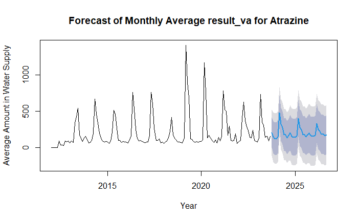

```r
result <- forecast_chemical(
  chemical_name = "Atrazine",
  start_date = "2012-01-01",
  param_data = param_data,
  chemical_data = chemical_data,
  forecast_horizon = 36
)
```

```r
result
```

```
$model
Series: result_va_ts_monthly
ARIMA(1,0,0)(2,0,0)[12] with non-zero mean

Coefficients:
         ar1    sar1    sar2      mean
      0.4224  0.4888  0.1316  186.4247
s.e.  0.0769  0.0848  0.0850   52.9737

sigma^2 = 26271:  log likelihood = -918.06
AIC=1846.12   AICc=1846.56   BIC=1860.86

$forecast
```

|  | Point Forecast | Lo 80 | Hi 80 | Lo 95 | Hi 95 |
| --- | --- | --- | --- | --- | --- |
| Oct 2023 | 206.7542 | -0.9627693 | 414.4711 | -110.92147 | 524.4298 |
| Nov 2023 | 144.3263 | -81.1631498 | 369.8158 | -200.53006 | 489.1827 |
| Dec 2023 | 119.8762 | -108.6393367 | 348.3918 | -229.60817 | 469.3606 |
| Jan 2024 | 119.2531 | -109.7982370 | 348.3045 | -231.05070 | 469.5569 |
| Feb 2024 | 150.2334 | -78.9134265 | 379.3802 | -200.21643 | 500.6832 |
| Mar 2024 | 481.0344 | 251.8705034 | 710.1982 | 130.55849 | 831.5102 |
| Apr 2024 | 321.8427 | 92.6757852 | 551.0096 | -28.63784 | 672.3232 |
| May 2024 | 272.9874 | 43.8199581 | 502.1548 | -77.49396 | 623.4687 |
| Jun 2024 | 175.2758 | -53.8917552 | 404.4433 | -175.20572 | 525.7573 |
| Jul 2024 | 178.1494 | -51.0181315 | 407.3170 | -172.33211 | 528.6309 |

[output cut: 26 more lines]

```
NA
```

Benzene SARIMA forecast. Not enough data to predict anything with the model.

```
The forecast indicates no significant change over the forecast period.Series: result_va_ts_monthly
ARIMA(0,0,0) with non-zero mean

Coefficients:
        mean
      8.8200
s.e.  1.3542

sigma^2 = 148.6:  log likelihood = -313.05
AIC=630.1   AICc=630.26   BIC=634.87

Training set error measures:
                        ME     RMSE      MAE       MPE     MAPE      MASE       ACF1
Training set -3.098129e-15 12.11215 6.678332 -1437.831 1465.066 0.7630948 0.04636652
```

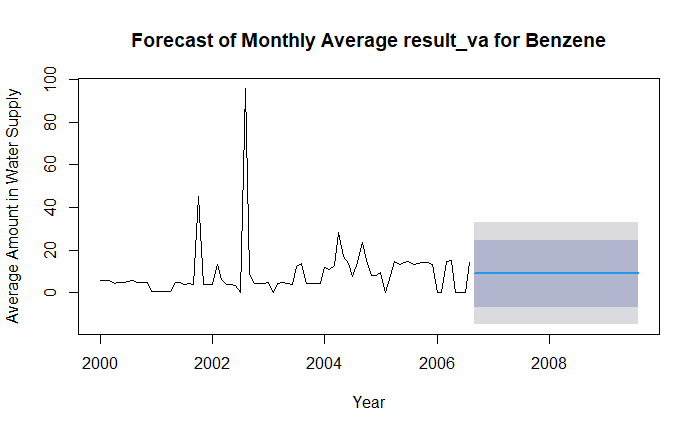

```r
result <- forecast_chemical(
  chemical_name = "Benzene",
  start_date = "2000-01-01",
  param_data = param_data,
  chemical_data = chemical_data,
  forecast_horizon = 36
)
```

```r
result
```

```
$model
Series: result_va_ts_monthly
ARIMA(0,0,0) with non-zero mean

Coefficients:
        mean
      8.8200
s.e.  1.3542

sigma^2 = 148.6:  log likelihood = -313.05
AIC=630.1   AICc=630.26   BIC=634.87

$forecast
```

|  | Point Forecast | Lo 80 | Hi 80 | Lo 95 | Hi 95 |
| --- | --- | --- | --- | --- | --- |
| Sep 2006 | 8.819998 | -6.80028 | 24.44028 | -15.06916 | 32.70915 |
| Oct 2006 | 8.819998 | -6.80028 | 24.44028 | -15.06916 | 32.70915 |
| Nov 2006 | 8.819998 | -6.80028 | 24.44028 | -15.06916 | 32.70915 |
| Dec 2006 | 8.819998 | -6.80028 | 24.44028 | -15.06916 | 32.70915 |
| Jan 2007 | 8.819998 | -6.80028 | 24.44028 | -15.06916 | 32.70915 |
| Feb 2007 | 8.819998 | -6.80028 | 24.44028 | -15.06916 | 32.70915 |
| Mar 2007 | 8.819998 | -6.80028 | 24.44028 | -15.06916 | 32.70915 |
| Apr 2007 | 8.819998 | -6.80028 | 24.44028 | -15.06916 | 32.70915 |
| May 2007 | 8.819998 | -6.80028 | 24.44028 | -15.06916 | 32.70915 |
| Jun 2007 | 8.819998 | -6.80028 | 24.44028 | -15.06916 | 32.70915 |

[output cut: 26 more lines]

```
NA
```

Metolachlor SARIMA forecast. Found post 2012 was where most measurements happen. Increase detected

```
The forecast indicates an increase of 20.30976 over the next 60 months.
Series: result_va_ts_monthly
ARIMA(3,1,1)(2,0,0)[12]

Coefficients:
         ar1      ar2      ar3      ma1    sar1    sar2
      0.4670  -0.0092  -0.0830  -0.9430  0.2009  0.2915
s.e.  0.0938   0.0947   0.0904   0.0306  0.0843  0.0856

sigma^2 = 5145:  log likelihood = -795.94
AIC=1605.88   AICc=1606.73   BIC=1626.48

Training set error measures:
                   ME     RMSE      MAE       MPE     MAPE      MASE        ACF1
Training set 8.180157 69.92323 48.94842 -2.731818 30.29614 0.6899594 -0.01712536
```

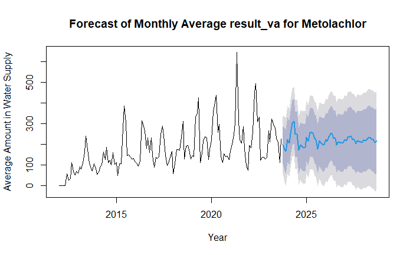

```r
result <- forecast_chemical(
  chemical_name = "Metolachlor",
  start_date = "2012-01-01",
  param_data = param_data,
  chemical_data = chemical_data,
  forecast_horizon = 60
)
```

```r
result
```

```
$model
Series: result_va_ts_monthly
ARIMA(3,1,1)(2,0,0)[12]

Coefficients:
         ar1      ar2      ar3      ma1    sar1    sar2
      0.4670  -0.0092  -0.0830  -0.9430  0.2009  0.2915
s.e.  0.0938   0.0947   0.0904   0.0306  0.0843  0.0856

sigma^2 = 5145:  log likelihood = -795.94
AIC=1605.88   AICc=1606.73   BIC=1626.48

$forecast
```

|  | Point Forecast | Lo 80 | Hi 80 | Lo 95 | Hi 95 |
| --- | --- | --- | --- | --- | --- |
| Oct 2023 | 197.0880 | 105.16698 | 289.0090 | 56.5069437 | 337.6690 |
| Nov 2023 | 175.6214 | 71.84622 | 279.3967 | 16.9109318 | 334.3320 |
| Dec 2023 | 165.2023 | 58.00066 | 272.4039 | 1.2515446 | 329.1530 |
| Jan 2024 | 223.1507 | 115.50947 | 330.7920 | 58.5276290 | 387.7738 |
| Feb 2024 | 207.5748 | 99.79162 | 315.3581 | 42.7346376 | 372.4150 |
| Mar 2024 | 252.7217 | 144.79833 | 360.6450 | 87.6671505 | 417.7762 |
| Apr 2024 | 302.7518 | 194.60507 | 410.8986 | 137.3556384 | 468.1480 |
| May 2024 | 312.4816 | 204.04138 | 420.9218 | 146.6366019 | 478.3265 |
| Jun 2024 | 247.9121 | 139.14397 | 356.6803 | 81.5655813 | 414.2587 |
| Jul 2024 | 250.5685 | 141.46640 | 359.6705 | 83.7112589 | 417.4257 |

[output cut: 50 more lines]

```
NA
```

```
The forecast indicates an increase of 15.71984 over the next 36 months.
Series: result_va_ts_monthly
ARIMA(3,1,1)(2,0,0)[12]

Coefficients:
         ar1      ar2      ar3      ma1    sar1    sar2
      0.4670  -0.0092  -0.0830  -0.9430  0.2009  0.2915
s.e.  0.0938   0.0947   0.0904   0.0306  0.0843  0.0856

sigma^2 = 5145:  log likelihood = -795.94
AIC=1605.88   AICc=1606.73   BIC=1626.48

Training set error measures:
                   ME     RMSE      MAE       MPE     MAPE      MASE        ACF1
Training set 8.180157 69.92323 48.94842 -2.731818 30.29614 0.6899594 -0.01712536
```

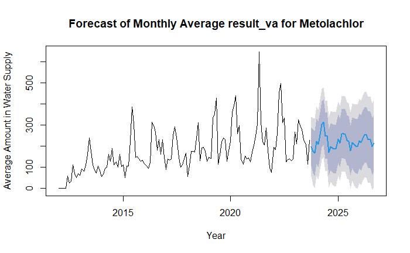

```r
result <- forecast_chemical(
  chemical_name = "Metolachlor",
  start_date = "2012-01-01",
  param_data = param_data,
  chemical_data = chemical_data,
  forecast_horizon = 36
)
```

```r
result
```

```
$model
Series: result_va_ts_monthly
ARIMA(3,1,1)(2,0,0)[12]

Coefficients:
         ar1      ar2      ar3      ma1    sar1    sar2
      0.4670  -0.0092  -0.0830  -0.9430  0.2009  0.2915
s.e.  0.0938   0.0947   0.0904   0.0306  0.0843  0.0856

sigma^2 = 5145:  log likelihood = -795.94
AIC=1605.88   AICc=1606.73   BIC=1626.48

$forecast
```

|  | Point Forecast | Lo 80 | Hi 80 | Lo 95 | Hi 95 |
| --- | --- | --- | --- | --- | --- |
| Oct 2023 | 197.0880 | 105.16698 | 289.0090 | 56.506944 | 337.6690 |
| Nov 2023 | 175.6214 | 71.84622 | 279.3967 | 16.910932 | 334.3320 |
| Dec 2023 | 165.2023 | 58.00066 | 272.4039 | 1.251545 | 329.1530 |
| Jan 2024 | 223.1507 | 115.50947 | 330.7920 | 58.527629 | 387.7738 |
| Feb 2024 | 207.5748 | 99.79162 | 315.3581 | 42.734638 | 372.4150 |
| Mar 2024 | 252.7217 | 144.79833 | 360.6450 | 87.667151 | 417.7762 |
| Apr 2024 | 302.7518 | 194.60507 | 410.8986 | 137.355638 | 468.1480 |
| May 2024 | 312.4816 | 204.04138 | 420.9218 | 146.636602 | 478.3265 |
| Jun 2024 | 247.9121 | 139.14397 | 356.6803 | 81.565581 | 414.2587 |
| Jul 2024 | 250.5685 | 141.46640 | 359.6705 | 83.711259 | 417.4257 |

[output cut: 26 more lines]

```
NA
```

Acetochlor SARIMA forecast. Increase detected

```
The forecast indicates an increase of 33.41419 over the next 36 months.
Series: result_va_ts_monthly
ARIMA(1,1,3)(1,0,1)[12]

Coefficients:
          ar1     ma1      ma2      ma3    sar1     sma1
      -0.7580  0.1155  -0.5537  -0.3269  0.8118  -0.6299
s.e.   0.1298  0.1511   0.1120   0.0859  0.1512   0.1961

sigma^2 = 4671:  log likelihood = -720.85
AIC=1455.7   AICc=1456.63   BIC=1475.66

Training set error measures:
                   ME     RMSE      MAE       MPE     MAPE      MASE         ACF1
Training set 2.732303 66.46761 45.09393 -7.075041 24.36949 0.7112018 -0.001749886
```

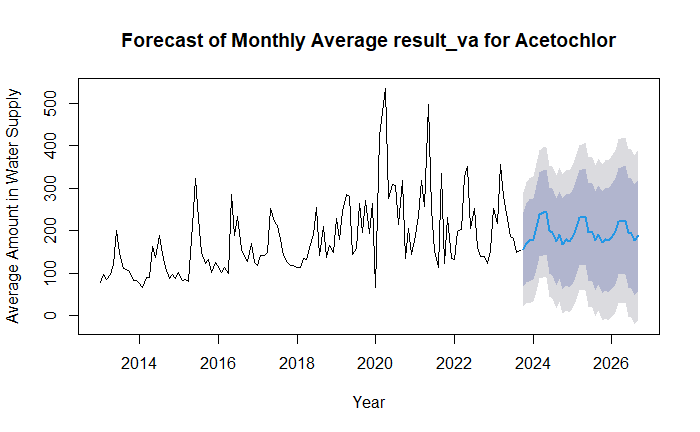

```r
result <- forecast_chemical(
  chemical_name = "Acetochlor",
  start_date = "2013-01-01",
  param_data = param_data,
  chemical_data = chemical_data,
  forecast_horizon = 36
)
```

```r
result
```

```
$model
Series: result_va_ts_monthly
ARIMA(1,1,3)(1,0,1)[12]

Coefficients:
          ar1     ma1      ma2      ma3    sar1     sma1
      -0.7580  0.1155  -0.5537  -0.3269  0.8118  -0.6299
s.e.   0.1298  0.1511   0.1120   0.0859  0.1512   0.1961

sigma^2 = 4671:  log likelihood = -720.85
AIC=1455.7   AICc=1456.63   BIC=1475.66

$forecast
```

|  | Point Forecast | Lo 80 | Hi 80 | Lo 95 | Hi 95 |
| --- | --- | --- | --- | --- | --- |
| Oct 2023 | 155.9643 | 68.37263 | 243.5561 | 22.004373 | 289.9243 |
| Nov 2023 | 170.8929 | 77.87231 | 263.9136 | 28.630168 | 313.1557 |
| Dec 2023 | 176.1579 | 79.71257 | 272.6032 | 28.657487 | 323.6583 |
| Jan 2024 | 180.2952 | 83.84165 | 276.7487 | 32.782230 | 327.8081 |
| Feb 2024 | 207.0990 | 108.67142 | 305.5265 | 56.567032 | 357.6309 |
| Mar 2024 | 238.2643 | 139.67166 | 336.8569 | 87.479886 | 389.0486 |
| Apr 2024 | 242.3073 | 142.38497 | 342.2296 | 89.489283 | 395.1253 |
| May 2024 | 243.8287 | 143.56596 | 344.0914 | 90.490089 | 397.1673 |
| Jun 2024 | 199.4642 | 98.18505 | 300.7434 | 44.571090 | 354.3574 |
| Jul 2024 | 196.7184 | 94.97382 | 298.4631 | 41.113471 | 352.3234 |

[output cut: 26 more lines]

```
NA
```

Diazinon SARIMA forecast. Data has inconsistent drops and peaks, no forecast

```
The forecast indicates a decrease of 0.02370768 over the next 36 months.
Series: result_va_ts_monthly
ARIMA(0,1,2)

Coefficients:
          ma1      ma2
      -0.6385  -0.1300
s.e.   0.0579   0.0557

sigma^2 = 23.09:  log likelihood = -848.16
AIC=1702.31   AICc=1702.4   BIC=1713.26

Training set error measures:
                     ME     RMSE      MAE        MPE     MAPE      MASE         ACF1
Training set 0.06639633 4.779556 3.344419 -0.8824121 7.284437 0.6176786 -0.001053708
```

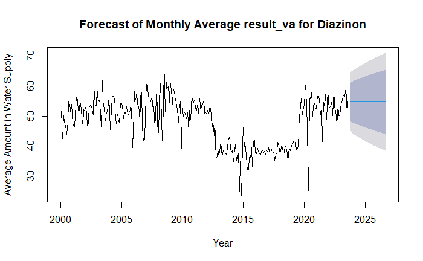

```r
result <- forecast_chemical(
  chemical_name = "Diazinon",
  start_date = "2000-01-01",
  param_data = param_data,
  chemical_data = chemical_data,
  forecast_horizon = 36
)
```

```r
result
```

```
$model
Series: result_va_ts_monthly
ARIMA(0,1,2)

Coefficients:
          ma1      ma2
      -0.6385  -0.1300
s.e.   0.0579   0.0557

sigma^2 = 23.09:  log likelihood = -848.16
AIC=1702.31   AICc=1702.4   BIC=1713.26

$forecast
```

|  | Point Forecast | Lo 80 | Hi 80 | Lo 95 | Hi 95 |
| --- | --- | --- | --- | --- | --- |
| Oct 2023 | 54.67059 | 48.51285 | 60.82833 | 45.25313 | 64.08804 |
| Nov 2023 | 54.64688 | 48.09910 | 61.19466 | 44.63292 | 64.66084 |
| Dec 2023 | 54.64688 | 47.94575 | 61.34801 | 44.39839 | 64.89538 |
| Jan 2024 | 54.64688 | 47.79583 | 61.49794 | 44.16910 | 65.12466 |
| Feb 2024 | 54.64688 | 47.64911 | 61.64465 | 43.94472 | 65.34904 |
| Mar 2024 | 54.64688 | 47.50542 | 61.78835 | 43.72495 | 65.56881 |
| Apr 2024 | 54.64688 | 47.36455 | 61.92921 | 43.50952 | 65.78424 |
| May 2024 | 54.64688 | 47.22636 | 62.06740 | 43.29818 | 65.99559 |
| Jun 2024 | 54.64688 | 47.09070 | 62.20306 | 43.09070 | 66.20306 |
| Jul 2024 | 54.64688 | 46.95743 | 62.33633 | 42.88688 | 66.40688 |

[output cut: 26 more lines]

```
NA
```

Azoxystrobin SARIMA forecast. Increase detected

```
The forecast indicates an increase of 2.598618 over the next 36 months.
Series: result_va_ts_monthly
ARIMA(1,0,0)(1,1,0)[12]

Coefficients:
         ar1     sar1
      0.3123  -0.4643
s.e.  0.0886   0.0955

sigma^2 = 21.82:  log likelihood = -367.59
AIC=741.17   AICc=741.37   BIC=749.63

Training set error measures:
                    ME     RMSE      MAE       MPE     MAPE      MASE       ACF1
Training set 0.4181157 4.424291 2.443488 -8.475068 41.71326 0.8250618 0.01634823
```

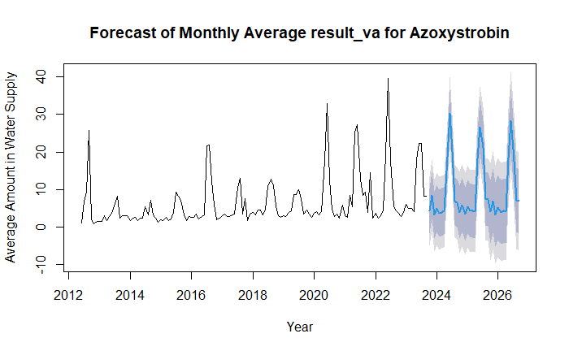

```r
result <- forecast_chemical(
  chemical_name = "Azoxystrobin",
  start_date = "2000-01-01",
  param_data = param_data,
  chemical_data = chemical_data,
  forecast_horizon = 36
)
```

```r
result
```

```
$model
Series: result_va_ts_monthly
ARIMA(1,0,0)(1,1,0)[12]

Coefficients:
         ar1     sar1
      0.3123  -0.4643
s.e.  0.0886   0.0955

sigma^2 = 21.82:  log likelihood = -367.59
AIC=741.17   AICc=741.37   BIC=749.63

$forecast
```

|  | Point Forecast | Lo 80 | Hi 80 | Lo 95 | Hi 95 |
| --- | --- | --- | --- | --- | --- |
| Oct 2023 | 4.261333 | -1.72511658 | 10.247783 | -4.894152 | 13.41682 |
| Nov 2023 | 8.402956 | 2.13130043 | 14.674613 | -1.188714 | 17.99463 |
| Dec 2023 | 3.184986 | -3.11380208 | 9.483773 | -6.448179 | 12.81815 |
| Jan 2024 | 4.907953 | -1.39347543 | 11.209381 | -4.729250 | 14.54516 |
| Feb 2024 | 3.680759 | -2.62092656 | 9.982445 | -5.956837 | 13.31836 |
| Mar 2024 | 3.993377 | -2.30833415 | 10.295088 | -5.644258 | 13.63101 |
| Apr 2024 | 4.263749 | -2.03796386 | 10.565463 | -5.373889 | 13.90139 |
| May 2024 | 18.522842 | 12.22112863 | 24.824556 | 8.885203 | 28.16048 |
| Jun 2024 | 30.294207 | 23.99249304 | 36.595920 | 20.656567 | 39.93185 |
| Jul 2024 | 20.157130 | 13.85541644 | 26.458844 | 10.519491 | 29.79477 |

[output cut: 26 more lines]

```
NA
```